# Spatial Data Analysis (450:320)

Class 1

The code behind the title page map:

```r
# Load libraries
library(terra)
library(viridis)
library(rnaturalearth)

# Query DEM data for Colombia
col_dem <- geodata::elevation_30s(country = "COL", path = tempdir())

# Query boundary of Colombia
col <- ne_countries(scale = 10, country = "Colombia")

# Plot the map to a png file
png("slides/figures/colombia-dem.png", bg = "transparent", height = 4,
    width = 4, res = 300, units = "in")

par(mar = c(0, 0, 0, 0))
plot(ext(col_dem), lty = 0, axes = FALSE)
plot(col$geometry, add = TRUE, border = "#f1faee", axes = FALSE, box = FALSE)
plot(col_dem, col = magma(100), add = TRUE, axes = FALSE, box = FALSE,
     legend = "bottom",
     plg = list(title = "Elevation (m)", cex = 0.7, col = "white", lwd = 2,
                title.col = "white", title.cex = 0.7))
dev.off()
```

## Introduction

- **Time:** Mon and Wed, 3:50 - 5: 10 PM
- **Lecture:** Lucy Stone Hall (LSH-B266), Livingston campus
- All course materials are hosted on its own site: https://sselp.github.io/sdawr/
- Canvas will be used **only** for posting grades.

## Communication

- We will use Google Chat [450:230(SP2026)](https://chat.google.com/room/AAQANhTZypY?cls=7) for all course-related communication.
  - Course announcements
  - Deadline reminders
  - Course readings, exercises and quizzes (these count toward participation!)
  - Asking questions and **helping each other**!
  - Direct messages for private conversations

## Need help?

- **Google chat**:
  - Arafat and I will do our best to respond to messages daily.
  - You are strongly encouraged to help and support each other.
- **Office hours**:
  - Lei Song: Mon and Wed, 2:50 - 3:50PM (or by appointment)
  - Md Arafat Hassan (Your TA): TBD

## Course Overview

- **By the end of this class, you should**
  - Be comfortable in working with R, including most common spatial functions
  - Have a good sense of where R is headed as a language
  - Know how to seek help properly when don’t know how to do something
  - Be using R as part of a *reproducible* workflow

## What is a reproducible workflow?

[figure not shown]

## Reproducibility

[figure not shown]

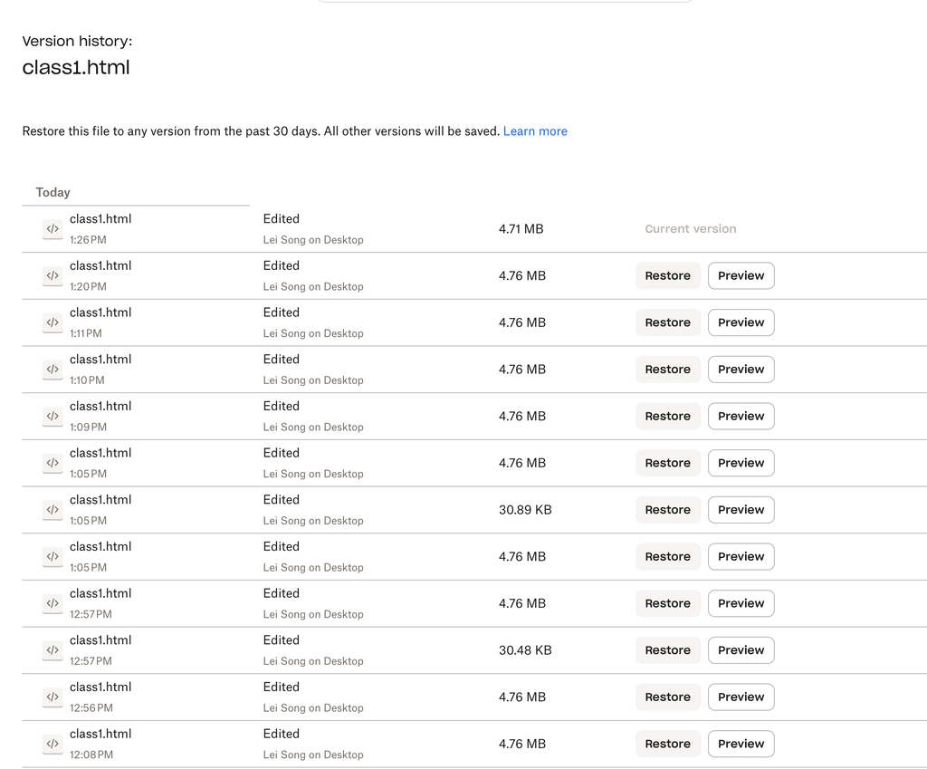

## Class Overview

- **Course approach**
  - (Largely) flipped model and emphasis on problem solving
    - Programming should be fun! (or at least intriguing)
- **Basic policies**
  - Attendance and communication
  - Attention to detail

## Course Requirements

What you need to do:

| Component | Grade |
| --- | --- |
| Practical assignments (n = 5) | 40% |
| Participation | 10% |
| Overview for final project | 10% |
| Oral defense for final project | 10% |
| Final project | 30% |

## Practical Assignments

**There will be a quiz-based grade refinement for all assignments.** Each assignment is followed by an in-class, closed-book quiz consisting of **10 questions** directly related to the programming tasks you just completed. Your final score for the assignment will be refined by your quiz performance according to the following tiers:

| Quiz Score | Assignment credit |
| --- | --- |
| 8-10 | 100% |
| 6-7 | 85% |
| 4-5 | 70% |
| 0-3 | 60% |
| Miss | 0% |

## Final Project

- Project overview (10%)
- Project oral defense (10%)
- Final project (30%)
  - Presentation
  - Final report
- Check details on the page of [projects](https://sselp.github.io/sdawr/projects.html)

## More Details

- Check our course [Syllabus](https://sselp.github.io/sdawr/syllabus.html)
- Grading will be based on the rubrics found under the [Assessment](https://sselp.github.io/sdawr/assessment.html)

## Let’s Get Set Up!

- [Software installation](https://sselp.github.io/sdawr/software-installation.html)
- **Very important!** Install everything this week. If you run into any issues, don’t hesitate to ask for help.

## Homework

- Go to our [course site](https://sselp.github.io/sdawr/) to check everything.
- Read [Unit1-Module 1](https://sselp.github.io/sdawr/unit1-module1.html) before *section 3.2.1*, *section 1.7 Style* in [Syllabus](https://sselp.github.io/sdawr/syllabus.html), and cheatsheet of RStudio and R markdown on the page of [Cheatsheets](https://sselp.github.io/sdawr/cheatsheets.html).
- Get yourself a GitHub account, if you haven’t
- Send us your GitHub name (**!!**)
- Install all necessary software on your local computer(s) if you haven’t today.
- Set up your personal access token following section 2.1 in [Git/GitHub](https://sselp.github.io/sdawr/git-github.html)).

## Next Class

- R package and R markdown.
- Set up your package!